# Simulate Cell Type Confounding

Chris McKennan

2016-02-05

**Last updated:** 2016-02-10

**Code version:** af905468b33b4013704c0b79c5ce75fabcdd5440

The purpose of this is to simulate data from the model $Y_{p \times n} = B_{p \times d}X_{d \times n} + L_{p \times k}B_{k \times d}^*X + LW_{k \times n} + Z_{p \times k'}\Gamma_{k' \times n} + E$. We want to know if we can get a reasonable estimate for $B$ using our proposed methods. We will let $W$ be the matrix of cell types. To start off, we will assume the covariates $X$ are simply disease status indicators, i.e. $d = 2$.

## Load required functions

```r
library(minfi)
```

```
locfit 1.5-9.1   2013-03-22
```

```r
library('IlluminaHumanMethylation450kmanifest')
library('IlluminaHumanMethylation450kanno.ilmn12.hg19')
library('FlowSorted.Blood.450k')      ##Methylation data on 6 males, 10 cell types; RGset object
library('RefFreeEWAS')
library('nlme')
library('corpcor')
library('sva')
source("../R/SimulateData.R")
```

## Preliminary analysis to get an idea of effect sizes of $B$ and $L$.

Get the data into R and initialize global variables.

```r
path.LPS.kids <- '/Users/Chris/Desktop/Uchicago/Nicolae/DNAMethylation/MichellesData/HTkids_cellprop/HTkids_LPS_covar_ImpAct_10115.txt'
path.methylation <- '/Users/Chris/Desktop/Uchicago/Nicolae/DNAMethylation/MichellesData/Hutterite_Methylation_data/Meth_covar_allsamp_impcells_10115.txt'
data.cov <- data.frame(read.table(path.methylation, sep="\t", quote="\"", dec=".", header=T, check.names=F))
data.LPS <- data.frame(read.table(path.LPS.kids, sep="\t", quote="\"", dec=".", header=T, check.names=F))
cell.names <- colnames(data.LPS)[(ncol(data.LPS) - 5):ncol(data.LPS)]
n.cells <- length(cell.names)
n.ind <- nrow(data.LPS)
ind.ids.cell <- data.LPS$Rowid    #IDs of individuals with cell type data
ind.ids.covar <- data.cov$Rowid   #IDs of individuals in complete covariate file
```

Load Michele’s data

```r
#Load SWAN-normalized data
#Variables are Mset.swan.norm and rgset
load(file="/Users/Chris/Desktop/Uchicago/Nicolae/DNAMethylation/MichellesData/MyWork/SavedObjects/Rfile.RData")
meth.norm <- getMeth(Mset.swan.norm)
unmeth.norm <- getUnmeth(Mset.swan.norm)
beta.values <- meth.norm/(meth.norm+unmeth.norm+100)  #These are ordered by row in data.cov
```

Identify columns of the data that correspond to the data that I have in data.LPS (i.e. cell type data) and perform a regression. Note that I have not removed CHIP effect. I am only interested in getting an idea of the relative effects of cell type and asthma status.

```r
col.use <- match(ind.ids.cell, ind.ids.covar)
beta.cell <- beta.values[,col.use]
M.cell <- log(beta.cell/(1-beta.cell))
m <- nrow(M.cell); n <- ncol(M.cell)  #m = #CpG sites; n = #individuals
model.mat <- model.matrix(~Tcell.act + Bcell.act + Eos.act + Neut.act + Mono.act + asthma, data=data.LPS)
beta.op <- solve(t(model.mat) %*% model.mat, t(model.mat))
H <- model.mat %*% beta.op
H.perp <- diag(1,nrow(H)) - H

coef.M <- beta.op %*% t(M.cell)
coef.beta <- beta.op %*% t(beta.cell)
var.mat <- solve(t(model.mat) %*% model.mat)
var.effects <- rep(NA, m)
stand.effects <- array(NA, dim=dim(coef.M))
for (p in 1:m) {
  tmp.site <- cbind(M.cell[p,])
  var.effects[p] <- t(tmp.site) %*% H.perp %*% tmp.site/(n - ncol(model.mat))
  stand.effects[,p] <- 1/sqrt(var.effects[p]) * diag(1/sqrt(diag(var.mat))) %*% cbind(coef.M[,p])
}
```

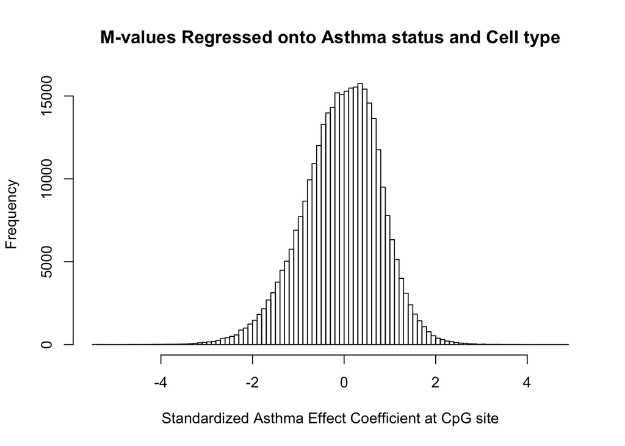

```r
beta.disease <- stand.effects[7,]   #My disease effects. These are quite large in comparison to the cell effects
hist(beta.disease, xlab='Standardized Asthma Effect Coefficient at CpG site', main='M-values Regressed onto Asthma status and Cell type', breaks=90)
```

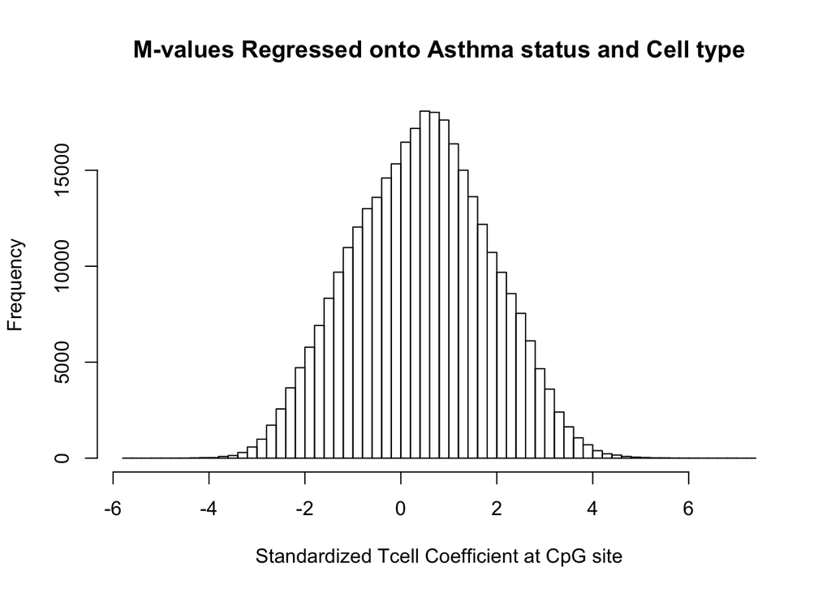

```r
hist(stand.effects[2,], xlab='Standardized Tcell Coefficient at CpG site', main='M-values Regressed onto Asthma status and Cell type', breaks=90)
```

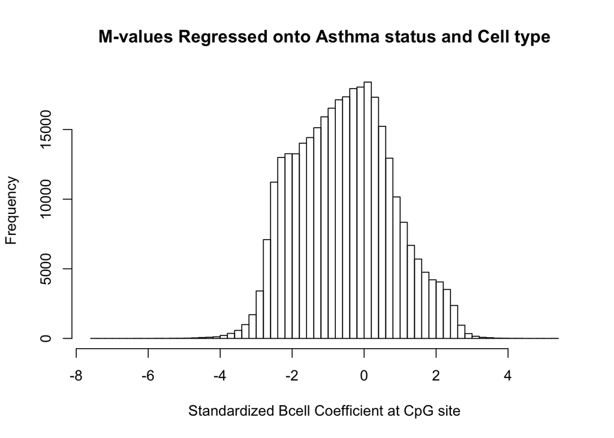

```r
hist(stand.effects[3,], xlab='Standardized Bcell Coefficient at CpG site', main='M-values Regressed onto Asthma status and Cell type', breaks=90)
```

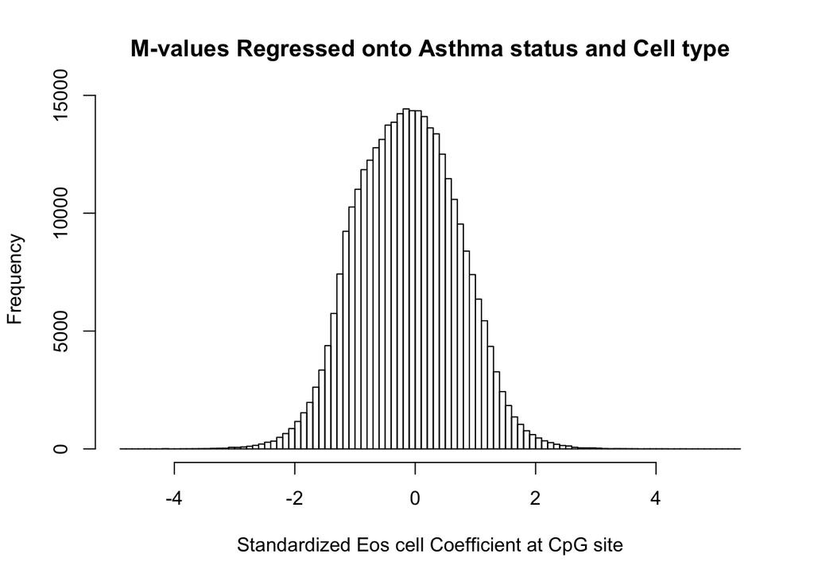

```r
hist(stand.effects[4,], xlab='Standardized Eos cell Coefficient at CpG site', main='M-values Regressed onto Asthma status and Cell type', breaks=90)
```

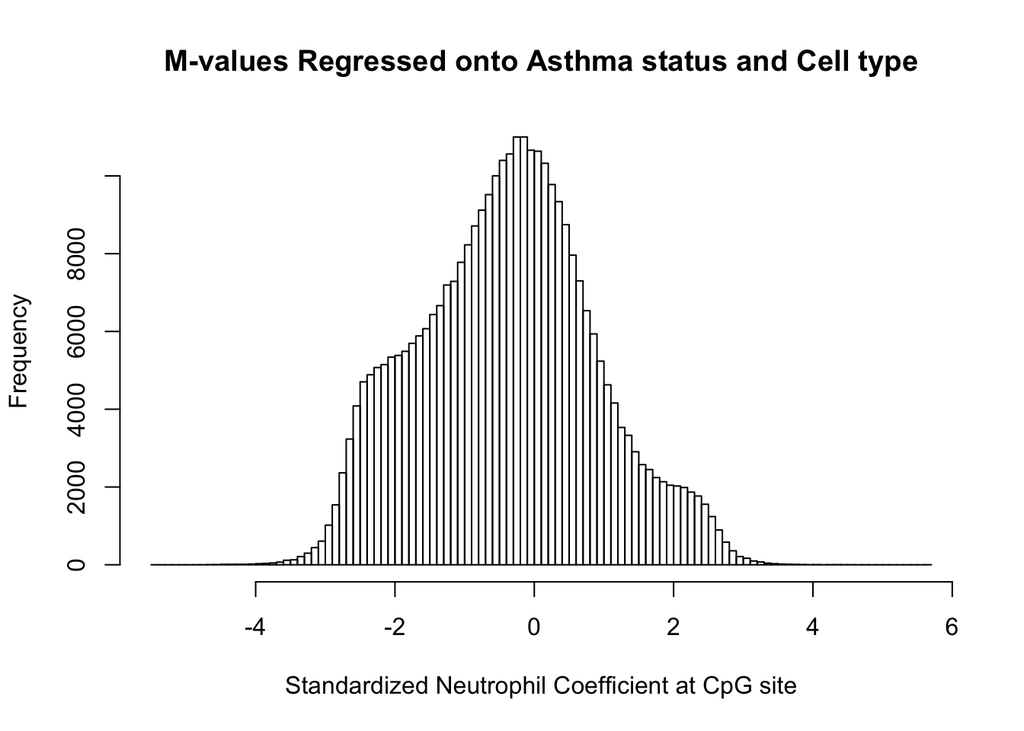

```r
hist(stand.effects[5,], xlab='Standardized Neutrophil Coefficient at CpG site', main='M-values Regressed onto Asthma status and Cell type', breaks=90)
```

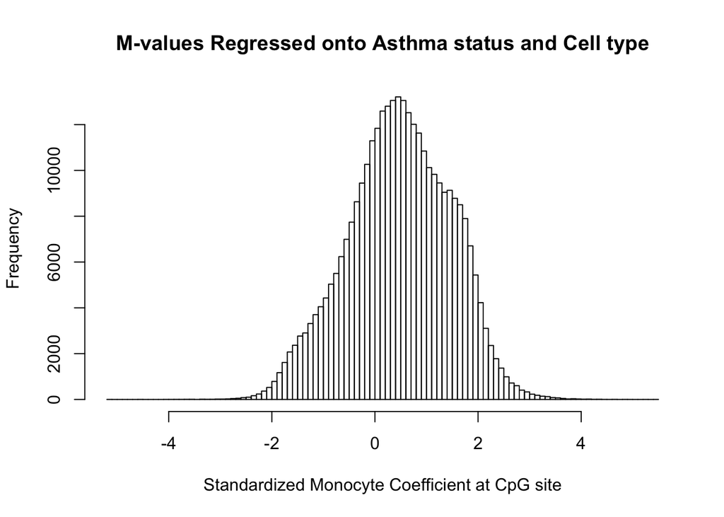

```r
hist(stand.effects[6,], xlab='Standardized Monocyte Coefficient at CpG site', main='M-values Regressed onto Asthma status and Cell type', breaks=90)
```

## Simulate CpG expression

To simulate data, I will use ONLY the covariate disease status and will simulate $B$ from a normal distribution with $\sigma^2$ approximately equal to $\text{Var}\left(\hat{B}\right)$ above. There will be 3 cell types, so the confounding dimension should be only 2. To start, I will use 1,000 CpG sites and 50 indivuduals. Note that $\frac{p}{n} \approx 400$ in real data, so we are giving the method generous numbers.

```r
n <- 50; p <- 1e3
p.disease <- 0.5
fract.B <- 1   ##B will be simulated from N(0, v), where v = sigma.celleffect/sqrt(pi)/fract.B. It controls the relative size of the methylation effect

x.asthma <- sort(rbinom(n, 1, p.disease))
X.sim <- rbind(rep(1, n), x.asthma)
coef.cell <- c(0.1, 0.1)   #asthma causes increases in both cell types (same for all genes)
p.cell <- c(0.35, 0.35)   #Without disease, this is the mean of both cell types
L <- 5*t(coef.M[c(2,4),sample((1:m), p, replace=T)])  ## p x k matrix
WX <- cbind(p.cell, coef.cell) %*% X.sim + rbind(0.08*rnorm(n), 0.08*rnorm(n))  ##W(X) ~ MN(B*X, I, I), a k x n matrix. This is the cell type for each individual, which is a function of the covariates (albeit a weak relationship)
CellEffect <- L %*% WX
sd.celleffect <- sd(apply(CellEffect, 1, mean))   #I want the asthma effect to be smaller than the average cell type effect
B <- sd.celleffect/sqrt(pi)/fract.B * rnorm(p)
M.main <- cbind(B) %*% rbind(x.asthma) + CellEffect
sd.all <- apply(M.main, 1, sd)
E <- sample(sd.all, p, replace=T)/2
M.sim <- M.main + diag(E) %*% matrix(rnorm(p*n), nrow=p, ncol=n)
```

## Try to estimate $B$ from the simulated data.

I will do this first by rotating by letting $X_{d \times n} = U \Sigma V^T$ and rotating M.sim by $V$ so that the last $n - d$ columns of M.sim do not depend on the covariates $X$, only the latent factors.

```r
svd.X <- svd(X.sim)
V.x <- svd.X$v    ##This is only n x d. We need to add to this
tmp.mat <- cbind(V.x, diag(n))
V.rotate <- qr.Q(qr(tmp.mat))   ##Complete V, where the first two columns are V.x
M.sim.rot <- M.sim %*% V.rotate   ##Rotate M.sim so that last n-d columns don't depend on X
d <- length(svd.X$d)
M.rot.L <- M.sim.rot[,(d+1):n]  ##This matrix should just be LWV + EV with nothing that depends on X
```

Use a simple SVD to estimate L and then project $Y$ onto $L_{\perp}$ to estimate $B$. Inependently permute the rows of M.rot.L to remove any hidden structure to estimate the latent dimension.

```r
eig.M <- svd(M.rot.L)
norm.eig.values.M <- eig.M$d^2/sum(eig.M$d^2)
p.values.eigs <- rep(0, n-d)
n.boot <- 100
for (b in 1:n.boot) {
  X.b <- PermMat(M.rot.L)
  eig.values.b <- svd(X.b)$d[1:(n-d)]
  norm.eig.values.b <- eig.values.b^2/sum(eig.values.b^2)
  ind.b <- as.numeric(norm.eig.values.M > norm.eig.values.b)

  p.values.eigs <- p.values.eigs + ind.b/n.boot
}
k <- which(p.values.eigs < 0.95)[1] - 1   ##Naive estimate of the latent dimension
naive.WV <- eig.M$v[,1:k]
naive.L <- eig.M$u[,1:k]
Relative.Fnorm <- norm(L %*% solve(t(L)%*%L, t(L)) - naive.L %*% solve(t(naive.L)%*%naive.L, t(naive.L)), "F")/ncol(L)   #Relative Frobenius norm

##Compute angle between subspaces##
tmp.eig <- svd(L %*% solve(t(L)%*%L, t(L)) - naive.L %*% solve(t(naive.L)%*%naive.L, t(naive.L)), nu=1, nv=1)
tmp.u <- tmp.eig$u[,1]
tmp.dist <- tmp.eig$d[1]
u.projL <- L %*% solve(t(L)%*%L, t(L)) %*% cbind(tmp.u); u.projL.naive <- naive.L %*% solve(t(naive.L)%*%naive.L, t(naive.L)) %*% cbind(tmp.u)
theta <- acos( (sum(u.projL*u.projL) + sum(u.projL.naive*u.projL.naive) - tmp.dist^2)/(2 * sqrt(sum(u.projL*u.projL)) * sqrt(sum(u.projL.naive*u.projL.naive))) )   ##Maximum angle between the two subspaces

##Project M.sim onto L.perp and estimate B##
Lnaive.perp <- diag(p) - naive.L %*% solve(t(naive.L)%*%naive.L, t(naive.L))
L.perp <- diag(p) - L %*% solve(t(L)%*%L, t(L))
M.sim.L.perp <- L.perp %*% M.sim
M.sim.Lnaive.perp <- Lnaive.perp %*% M.sim

B.operator <- solve(X.sim %*% t(X.sim), X.sim)
Bhat.L.perp <- M.sim.L.perp %*% t(B.operator)
Bhat.Lnaive.perp <- M.sim.Lnaive.perp %*% t(B.operator)
Bhat.noL <- M.sim %*% t(B.operator)
```

## Plot results for $\hat{B}$

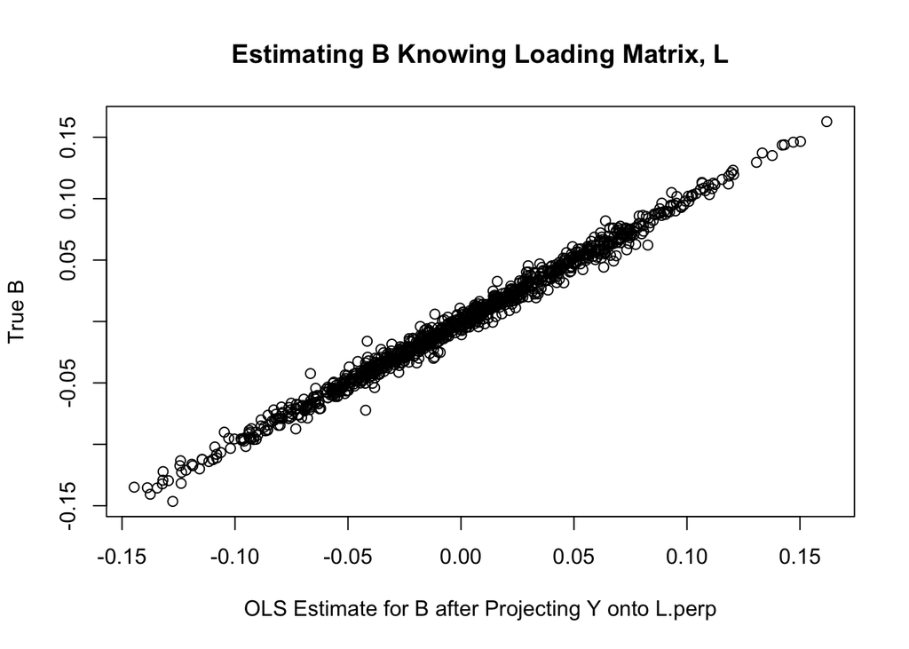

```r
plot(Bhat.L.perp[,2], B, main='Estimating B Knowing Loading Matrix, L', xlab='OLS Estimate for B after Projecting Y onto L.perp', ylab="True B")
```

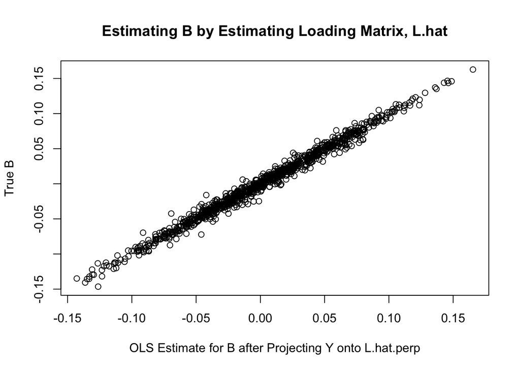

```r
plot(Bhat.Lnaive.perp[,2], B, main='Estimating B by Estimating Loading Matrix, L.hat', xlab='OLS Estimate for B after Projecting Y onto L.hat.perp', ylab="True B")  ##Note that this is identical to what Houseman does...
```

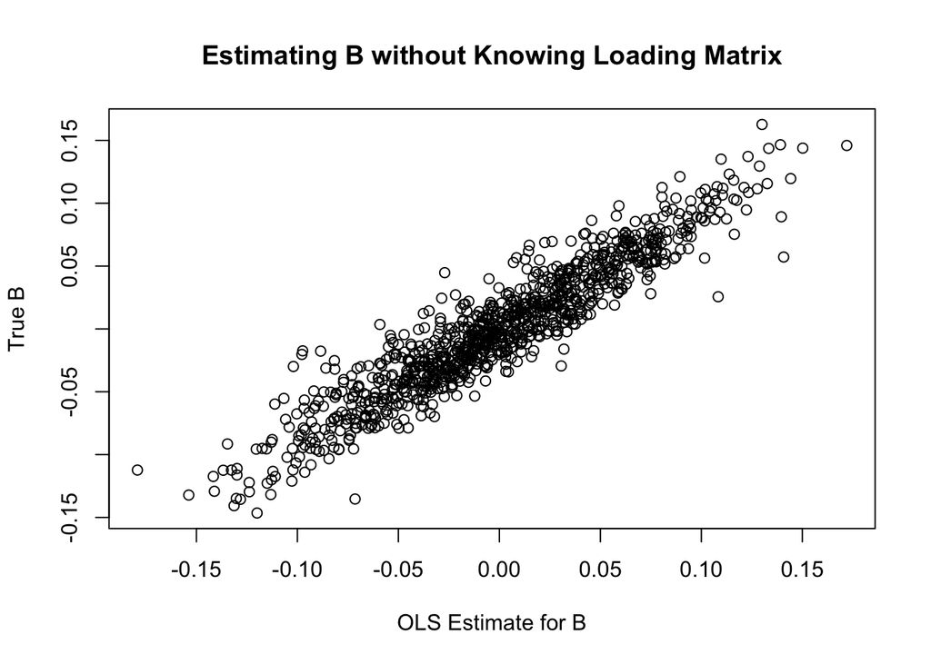

```r
plot(Bhat.noL[,2], B, main='Estimating B without Knowing Loading Matrix', xlab='OLS Estimate for B', ylab="True B")
```